# Artificial Intelligence

## CA5 First Phase

### Ava KazemiNejad 810197675

# Imported Libraries

```python
import numpy as np
import pandas as pd
import matplotlib.pyplot as plt
import seaborn as sns
```

# Read Files Data

```python
TrainData = pd.read_csv("/content/TrainImgs.csv", header=None)
TestData = pd.read_csv("/content/TestImgs.csv", header=None)
TrainLabels = pd.read_csv("/content/TrainLabels.csv", header=None)
TestLabels = pd.read_csv("/content/TestLabels.csv", header=None)
```

```python
TrainLabels.head()
```

|  | 0 |
| --- | --- |
| 0 | 1 |
| 1 | 1 |
| 2 | 1 |
| 3 | 1 |
| 4 | 1 |

```python
TrainData = TrainData[TrainLabels[0]<17]
TestData = TestData[TestLabels[0]<17]
TrainLabels = TrainLabels[TrainLabels[0]<17]
TestLabels = TestLabels[TestLabels[0]<17]
TrainLabels = TrainLabels-1
TestLabels = TestLabels-1
```

# Review and Preprocessing

## Step 1:

### For Train Data:

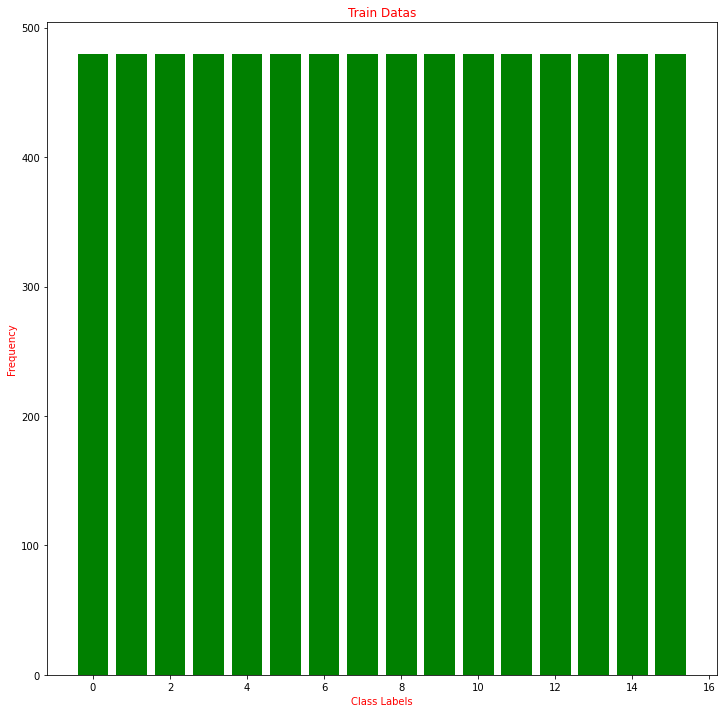

```python
frequencies = TrainLabels.value_counts()
Span = list(range(len(frequencies)))

plt.figure(figsize = (12, 12))

plt.bar(Span, frequencies, color = 'green')
plt.title("Train Datas", color = 'red')
plt.xlabel("Class Labels", color = 'red')
plt.ylabel("Frequency", color = 'red')
plt.show()
```

### For Test Data:

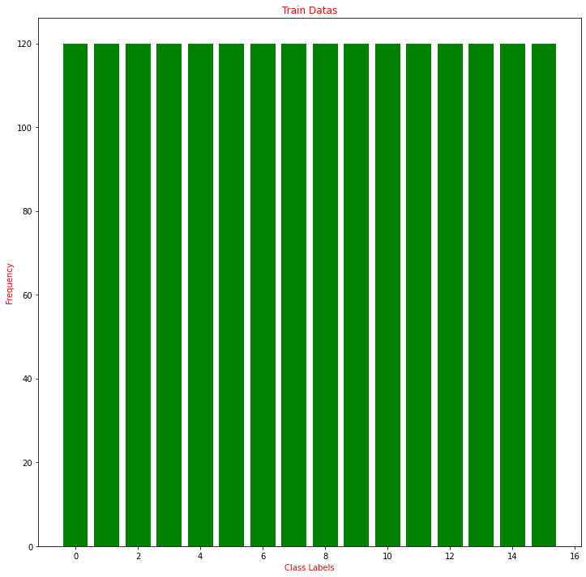

```python
frequencies = TestLabels.value_counts()
Span = list(range(len(frequencies)))

plt.figure(figsize = (12, 12))

plt.bar(Span, frequencies, color = 'green')
plt.title("Train Datas", color = 'red')
plt.xlabel("Class Labels", color = 'red')
plt.ylabel("Frequency", color = 'red')
plt.show()
```

## Step 3:

### Normalization:

When we normalize the data, all the data is in the range between zero and one. This speeds up computations because it simplifies math operations. And will reduce overflow. It also reduces the chance of the gradient exploding. Also, if our weights are updated with smaller amounts, our model will be more stable.

```python
TrainData = TrainData / 255.
TestData = TestData / 255.
```

```python
TrainData = TrainData.to_numpy()
TestData = TestData.to_numpy()
TrainLabels = TrainLabels.to_numpy()
TestLabels = TestLabels.to_numpy()
```

# Completing parts of the neural network

## Step 1: Dataloader

```python
class Dataloader:

    def __init__(self, data, labels, n_classes, batch_size=None, shuffle=False):

        assert len(data) == len(labels)
        self.__n_classes = n_classes
        self.__batch_size = batch_size
        self.__shuffle = shuffle
        self.__data = data
        self.__onehot_labels = self.__onehot(labels, self.__n_classes)

    def __onehot(self, labels, n_classes):

        m = self.__data.shape[0]
        onehot_matrix = np.zeros((m, 16))
        onehot_matrix[list(range(m)), labels.T] = 1
        return onehot_matrix

    def __shuffle_dataset(self):
        m = len(self.__data)
        shuffler = np.random.permutation(m)
        self.__data = self.__data[shuffler]
        self.__onehot_labels = self.__onehot_labels[shuffler]


    def __iter__(self):

        if self.__shuffle:
            self.__shuffle_dataset()

        if self.__batch_size==None:
            yield (np.matrix(self.__data), np.matrix(self.__onehot_labels))
            return

        for idx in range(0, len(self.__data), self.__batch_size):
            yield (np.matrix(self.__data[idx:idx+self.__batch_size]),
                   np.matrix(self.__onehot_labels[idx:idx+self.__batch_size]))
```

## Step 2: Activation Function

```python
# class Identical:

#     def __init__(self): pass

#     def __val(self, matrix):
#         return matrix.astype('float')

#     def derivative(self, matrix):
#         identical_derivative = np.ones(matrix.shape)
#         return identical_derivative.astype('float')

#     def __call__(self, matrix):
#         return self.__val(matrix)


# class Relu:

#     def __init__(self): pass

#     def __relu(self, matrix):
#         matrix = matrix.astype('float')
#         relu_value = matrix.clip(min = 0)
#         return relu_value

#     def derivative(self, matrix):
#         matrix = matrix.astype('float')
#         relu_derivative = np.ones(matrix.shape)
#         relu_derivative[matrix <= 0] = 0
#         return relu_derivative

#     def __call__(self, matrix):
#         return self.__relu(matrix)



# class LeakyRelu:

#     def __init__(self, negative_slope=0.01):
#         self.negative_slope = 0.01

#     def __val(self, matrix):
#         matrix = matrix.astype('float')
#         matrix[matrix < 0] =  self.negative_slope * matrix[matrix <= 0]
#         leacky_relu_value = matrix
#         return leacky_relu_value

#     def derivative(self, matrix):
#         matrix = matrix.astype('float')
#         leaky_relu_derivative = np.ones(matrix.shape)
#         leaky_relu_derivative[matrix < 0] = self.negative_slope
#         return leaky_relu_derivative

#     def __call__(self, matrix):
#         return self.__val(matrix)


# class Sigmoid:

#     def __init__(self): pass

#     def __val(self, matrix):
#         matrix = matrix.astype('float')
#         matrix = (matrix - matrix.max(axis=1))
#         exp = np.exp(matrix)
#         value = 1 / (1 + (1 / exp))
#         return value

#     def derivative(self, matrix):
#         matrix = matrix.astype('float')
#         sigmoid_value = self.__val(self, matrix)
#         sigmoid_derivative = sigmoid_value * (1 - sigmoid_value)
#         return sigmoid_derivative

#     def __call__(self, matrix):
#         return self.__val(matrix)


# class Softmax:

#     def __init__(self): pass

#     def __val(self, matrix):
#         a = matrix - matrix.max(axis=1)
#         b = np.exp(a)
#         c = np.sum(b, axis=1)
#         value = b / c
#         return value

#     def __call__(self, matrix):
#         return self.__val(matrix)

# class Tanh:

#     def __init__(self): pass

#     def __val(self, matrix):
#         matrix = np.matrix(matrix, dtype=float)
#         matrix = matrix - matrix.max(axis=1)
#         tanh_value = np.tanh(matrix)
#         return tanh_value

#     def derivative(self, matrix):
#         matrix = np.matrix(matrix, dtype=float)
#         matrix = matrix - matrix.max(axis=1)
#         tanh_value = np.tanh(matrix)
#         tanh_derivative = 1 - np.multiply(tanh_value, tanh_value)
#         return tanh_derivative

#     def __call__(self, matrix):
#         return self.__val(matrix)
#         value = 1 / (1 + (1 / exp))
#         der_value = np.multiply(value, (1 - value))
#         sigmoid_derivative = np.matrix(der_value, dtype=float)
#         return sigmoid_derivative

#     def __call__(self, matrix):
#         return self.__val(matrix)
```

```python
class Identical:

    def __init__(self): pass

    def __val(self, matrix):
        identical_value = np.matrix(matrix, dtype=float)
        return identical_value

    def derivative(self, matrix):
        temp = np.matrix(matrix, dtype=float)
        identical_derivative = np.matrix(np.full(np.shape(temp), 1.))
        return identical_derivative

    def __call__(self, matrix):
        return self.__val(matrix)


class Relu:

    def __init__(self): pass

    def __relu(self, matrix):
        matrix = np.matrix(matrix, dtype=float)
        matrix[matrix < 0] = 0
        relu_value = matrix
        return relu_value

    def derivative(self, matrix):
        matrix = np.matrix(matrix, dtype=float)
        matrix[matrix <= 0] = 0
        matrix[matrix > 0] = 1
        relu_derivative = matrix
        return relu_derivative

    def __call__(self, matrix):
        return self.__relu(matrix)


class LeakyRelu:

    def __init__(self, negative_slope=0.01):
        self.negative_slope = 0.01

    def __val(self, matrix):
        matrix = np.matrix(matrix, dtype=float)
        matrix = np.where(matrix > 0, matrix, matrix*self.negative_slope)
        leacky_relu_value = matrix
        return leacky_relu_value

    def derivative(self, matrix):
        matrix = np.matrix(matrix, dtype=float)
        matrix[matrix > 0] = 1
        matrix[matrix <= 0] = self.negative_slope
        leacky_relu_derivative = matrix
        return leacky_relu_derivative

    def __call__(self, matrix):
        return self.__val(matrix)


class Sigmoid:

    def __init__(self): pass

    def __val(self, matrix):
        exp = np.exp(matrix)
        value = 1 / (1 + (1 / exp))
        sigmoid_value = np.matrix(value, dtype=float)
        return sigmoid_value

    def derivative(self, matrix):
        exp = np.exp(matrix)
        value = 1 / (1 + (1 / exp))
        der_value = np.multiply(value, (1 - value))
        sigmoid_derivative = np.matrix(der_value, dtype=float)
        return sigmoid_derivative

    def __call__(self, matrix):
        return self.__val(matrix)


class Softmax:

    def __init__(self): pass

    def __val(self, matrix):
        a = matrix - matrix.max(1)
        b = np.exp(a)
        c = np.sum(b, axis=1)
        value = b / c
        softmax_value = np.matrix(value, dtype=float)
        return softmax_value

    def __call__(self, matrix):
        return self.__val(matrix)

class Tanh:

    def __init__(self): pass

    def __val(self, matrix):
        matrix = np.matrix(matrix, dtype=float)
        tanh_value = np.tanh(matrix)
        return tanh_value

    def derivative(self, matrix):
        matrix = np.matrix(matrix, dtype=float)
        tanh_value = np.tanh(matrix)
        tanh_derivative = 1 - np.multiply(tanh_value, tanh_value)
        return tanh_derivative

    def __call__(self, matrix):
        return self.__val(matrix)
```

## Loss function

```python
class CrossEntropy: #(with softmax)

    def __init__(self): pass

    def __val(self, true_val, expected_val):
        assert true_val.shape == expected_val.shape
        softmax = Softmax()
        new_true_val = softmax(true_val)
        temp = -1 * np.multiply(expected_val, np.ma.log(new_true_val))
        cross_entropy_value = np.sum(temp, axis = 1)
        return cross_entropy_value

    def derivative(self, true_val, expected_val):
        assert np.shape(true_val) == np.shape(expected_val)
        softmax = Softmax()
        new_true_val = softmax(true_val)
        cross_entropy_derivative = new_true_val - expected_val
        return cross_entropy_derivative

    def __call__(self, true_val, expected_val):
        return self.__val(true_val, expected_val)
```

## Layer

```python
class Layer:

    DEFAULT_LOW, DEFAULT_HIGH, DEFAULT_MEAN, DEFAULT_VAR = 0, 0.05, 0., 1.

    def __init__(self, input_size, output_size,
                 activation=Identical(), initial_weight='uniform', **initializing_parameters):

        assert type(initial_weight)==str, 'Undefined activation function!'

        self.__weight_initializer_dict = {'uniform':self.__uniform_weight, 'normal':self.__normal_weight}

        assert initial_weight in self.__weight_initializer_dict, 'Undefined weight initialization function!'


        self.__n_neurons = output_size
        weight_initializer = self.__weight_initializer_dict[initial_weight]
        self.__weight = weight_initializer(input_size, self.__n_neurons, **initializing_parameters)
        self.__bias = weight_initializer(1, self.__n_neurons, **initializing_parameters)
        self.__activation = activation

        self.__last_input = None
        self.__last_activation_input = None
        self.__last_activation_output = None
        self.__last_activation_derivative = None

    def forward(self, layer_input):
        assert np.ndim(layer_input)==2
        assert np.size(self.__weight,0) == np.size(layer_input,1)
        self.__last_input = layer_input
        self.__last_activation_input = np.matmul(self.__last_input, self.__weight) + self.__bias
        self.__last_activation_output = self.__activation( self.__last_activation_input)
        self.__last_activation_derivative = self.__activation.derivative(self.__last_activation_input)
        return self.__last_activation_output

    def update_weights(self, backprop_tensor, lr):
        assert np.ndim(backprop_tensor)==2
        assert np.size(backprop_tensor,0) == np.size(self.__last_activation_derivative,0)
        assert np.size(backprop_tensor,1) == self.__n_neurons

        pre_weight = self.__weight

        dl_dy = np.multiply(backprop_tensor, self.__last_activation_derivative)

        dl_dw = np.matmul(np.transpose(self.__last_input), dl_dy)
        self.__weight = self.__weight - (lr * dl_dw)

        array = np.matrix(np.ones(dl_dy.shape[0]))
        dl_dw = np.matmul(array, dl_dy)
        self.__bias -= lr * dl_dw

        backprop_tensor = np.matmul(dl_dy, np.transpose(pre_weight))

        return backprop_tensor

    def __uniform_weight(self, dim1, dim2, **initializing_parameters):
        low, high = self.DEFAULT_LOW, self.DEFAULT_HIGH
        if 'low' in initializing_parameters.keys(): low = initializing_parameters['low']
        if 'high' in initializing_parameters.keys(): high = initializing_parameters['high']
        weights = np.random.uniform(low, high, (dim1, dim2))
        return weights

    def __normal_weight(self, dim1, dim2, **initializing_parameters):
        mean, var = self.DEFAULT_MEAN, self.DEFAULT_VAR
        if 'mean' in initializing_parameters.keys(): mean = initializing_parameters['mean']
        if 'var' in initializing_parameters.keys(): var = initializing_parameters['var']
        weights = np.random.normal(mean, np.sqrt(var), (dim1, dim2))
        return weights

    @property
    def n_neurons(self): return self.__n_neurons

    @property
    def weight(self): return self.__weight

    @property
    def bias(self): return self.__bias

    @property
    def activation(self): return self.__activation
```

## Feed Forward NN

```python
class FeedForwardNN:

    def __init__(self, input_shape):

        self.__input_shape = input_shape
        self.__output_shape = None

        self.__layers_list = []

        self.__lr = None
        self.__loss = None

        self.train_result = list()
        self.test_result = list()
        self.train_labels_result = list()
        self.test_labels_result = list()
        self.train_flag = False
        self.test_flag = False


    def add_layer(self, n_neurons, activation=Relu(), initial_weight='uniform', **initializing_parameters):

        assert type(n_neurons)==int, "Invalid number of neurons for the layer!"
        assert n_neurons>0, "Invalid number of neurons for the layer!"

        n_prev_neurons = self.__input_shape if len(self.__layers_list)==0 else self.__layers_list[-1].n_neurons
        new_layer = Layer(n_prev_neurons, n_neurons, activation, initial_weight, **initializing_parameters)
        self.__layers_list.append(new_layer)
        self.__output_shape = self.__layers_list[-1].n_neurons


    def set_training_param(self, loss=CrossEntropy(), lr=1e-3):
        assert self.__layers_list, "Uncomplete model!"
        self.__loss = loss
        self.__lr = lr


    def forward(self, network_input, label=None, last_epoch=None):
        assert type(self.__output_shape) != None, "Model is not compiled!"

        for layer in self.__layers_list:
            network_input = layer.forward(network_input)

            if layer == self.__layers_list[len(self.__layers_list)-2] and last_epoch == True:

                if self.train_flag == True:
                    self.train_result.append(network_input)
                    self.train_labels_result.append(label)

                if self.test_flag == True:
                    self.test_result.append(network_input)
                    self.test_labels_result.append(label)

        network_output = network_input
        return network_output


    def fit(self, epochs, trainloader, testloader=None, print_results=True):

        assert type(self.__output_shape) != None, "Model is not compiled!"
        assert type(self.__lr) != None and type(self.__loss) != None, "Training paramenters are not set!"

        log = {"train_accuracy":[], "train_loss":[], "test_accuracy":[], "test_loss":[]}

        last_epoch = False

        for epoch in range(1, epochs+1):

            if print_results:
                print('Epoch {}:'.format(epoch))

            if epoch == epochs:
                last_epoch = True

            average_accuracy, average_loss = self.__train(trainloader, last_epoch)
            log['train_accuracy'].append(average_accuracy)
            log['train_loss'].append(average_loss)
            if print_results:
                print('\tTrain: Average Accuracy: {}\tAverage Loss: {}'.format(average_accuracy, average_loss))

            if type(testloader) != type(None):
                average_accuracy, average_loss = self.__test(testloader, last_epoch)
                log['test_accuracy'].append(average_accuracy)
                log['test_loss'].append(average_loss)
                if print_results:
                    print('\tTest: Average Accuracy: {}\tAverage Loss: {}'.format(average_accuracy, average_loss))

        return log


    def __train(self, trainloader, last_epoch=None):
        bach_accuracies, batch_losses = [], []
        for x_train, y_train in trainloader:
            batch_accuracy, batch_loss = self.__train_on_batch(x_train, y_train, last_epoch)
            bach_accuracies.append(batch_accuracy)
            batch_losses.append(batch_loss)
        return np.mean(bach_accuracies), np.mean(batch_losses)


    def __test(self, testloader, last_epoch=None):
        bach_accuracies, batch_losses = [], []
        for x_test, y_test in testloader:
            batch_accuracy, batch_loss = self.__test_on_batch(x_test, y_test, last_epoch)
            bach_accuracies.append(batch_accuracy)
            batch_losses.append(batch_loss)
        return np.mean(bach_accuracies), np.mean(batch_losses)


    def __train_on_batch(self, x_batch, y_batch, last_epoch=None):
        self.set_train_and_test_flag("train")

        f = self.forward(x_batch, y_batch, last_epoch)

        batch_accuracy = self.__compute_accuracy(f, y_batch)

        e = self.__loss(f, y_batch)
        batch_average_loss = np.sum(e) / len(e)

        self.__update_weights(f, y_batch)

        return (batch_accuracy, batch_average_loss)


    def __test_on_batch(self, x_batch, y_batch, last_epoch=None):
        self.set_train_and_test_flag("test")
        f = self.forward(x_batch, y_batch, last_epoch)

        batch_accuracy = self.__compute_accuracy(f, y_batch)

        e = self.__loss(f, y_batch)
        batch_average_loss = np.sum(e) / len(e)

        return (batch_accuracy, batch_average_loss)


    def __get_labels(self, outputs):
        labels = np.argmax(outputs, axis = 1)
        return labels


    def __compute_accuracy(self, output, expected_output):
        size = len(output)
        accuracy = (np.sum(self.__get_labels(output) == self.__get_labels(expected_output)) / size) * 100
        return accuracy


    def __update_weights(self, output, y_train):
        loss_der = self.__loss.derivative(output, y_train)
        for layer in reversed(self.__layers_list):
            loss_der = layer.update_weights(loss_der, self.__lr)
        return

    def get_result_lists(self):
        return self.train_result, self.test_result, self.train_labels_result, self.test_labels_result

    def set_train_and_test_flag(self, status):
        if status == "train":
            self.train_flag = True
            self.test_flag = False
        elif status == "test":
            self.test_flag = True
            self.train_flag = False
```

### Step 1:

## Training Sample Code

Sample code for building and training a model

```python
# Sample code for building and training a model

INPUT_SHAPE = 32*32
LEARNING_RATE = 0.005
EPOCHS = 100
TRAINLOADER = list()
TESTLOADER = list()

for i in Dataloader(TrainData, TrainLabels, 16, batch_size=32, shuffle=True):
    TRAINLOADER.append(i)

for i in  Dataloader(TestData, TestLabels, 16, batch_size=32, shuffle=True):
    TESTLOADER.append(i)

network = FeedForwardNN(INPUT_SHAPE)
network.add_layer(64, input_shape=INPUT_SHAPE, activation=Relu(), weight_initializer='normal')
network.add_layer(32, input_shape=INPUT_SHAPE, activation=Relu(), weight_initializer='normal')
network.add_layer(16, activation=Identical(), weight_initializer='normal')
network.set_training_param(loss=CrossEntropy(), lr=LEARNING_RATE)

log = network.fit(EPOCHS, TRAINLOADER, TESTLOADER)
```

```
Epoch 1:
	Train: Average Accuracy: 9.856770833333334	Average Loss: 2.6677581316597516
	Test: Average Accuracy: 12.604166666666666	Average Loss: 2.529036493923079
Epoch 2:
	Train: Average Accuracy: 17.890625	Average Loss: 2.3297318710607624
	Test: Average Accuracy: 24.583333333333332	Average Loss: 2.0497959151462437
Epoch 3:
	Train: Average Accuracy: 29.4140625	Average Loss: 1.905613359689776
	Test: Average Accuracy: 32.447916666666664	Average Loss: 1.7664032370384348
Epoch 4:
	Train: Average Accuracy: 35.872395833333336	Average Loss: 1.674952454760212
	Test: Average Accuracy: 37.34375	Average Loss: 1.6126923475737047
Epoch 5:
	Train: Average Accuracy: 43.697916666666664	Average Loss: 1.4831339638295007
	Test: Average Accuracy: 45.520833333333336	Average Loss: 1.4507003395363387
Epoch 6:
	Train: Average Accuracy: 51.4453125	Average Loss: 1.2723541667114617
	Test: Average Accuracy: 50.677083333333336	Average Loss: 1.28506617689792
Epoch 7:
	Train: Average Accuracy: 56.588541666666664	Average Loss: 1.1209538659548348
	Test: Average Accuracy: 54.270833333333336	Average Loss: 1.1743167055832444
Epoch 8:
	Train: Average Accuracy: 60.546875	Average Loss: 0.9943624795940302
	Test: Average Accuracy: 56.927083333333336	Average Loss: 1.1057986230403714
Epoch 9:
	Train: Average Accuracy: 63.90625	Average Loss: 0.8935178964649075
	Test: Average Accuracy: 59.427083333333336	Average Loss: 1.04153241252767
Epoch 10:
	Train: Average Accuracy: 67.35677083333333	Average Loss: 0.8127723009452161
	Test: Average Accuracy: 61.145833333333336	Average Loss: 1.0369461086497693
Epoch 11:
	Train: Average Accuracy: 70.22135416666667	Average Loss: 0.7475824999950726
	Test: Average Accuracy: 61.145833333333336	Average Loss: 1.0125761364377235
Epoch 12:
	Train: Average Accuracy: 72.99479166666667	Average Loss: 0.682939898933259
	Test: Average Accuracy: 63.229166666666664	Average Loss: 1.011862619384875
Epoch 13:
	Train: Average Accuracy: 75.09114583333333	Average Loss: 0.6260060157138265
	Test: Average Accuracy: 62.34375	Average Loss: 1.068311056495262
Epoch 14:
```

[output cut: 245 more lines]

```
Epoch 96:
	Train: Average Accuracy: 100.0	Average Loss: 0.0005475764330506166
	Test: Average Accuracy: 74.47916666666667	Average Loss: 2.0600918960560772
Epoch 97:
	Train: Average Accuracy: 100.0	Average Loss: 0.0005366765908713885
	Test: Average Accuracy: 74.53125	Average Loss: 2.0633302829383227
Epoch 98:
	Train: Average Accuracy: 100.0	Average Loss: 0.0005260252149047936
	Test: Average Accuracy: 74.63541666666667	Average Loss: 2.0663317883810084
Epoch 99:
	Train: Average Accuracy: 100.0	Average Loss: 0.0005161133739030011
	Test: Average Accuracy: 74.6875	Average Loss: 2.069539894406144
Epoch 100:
	Train: Average Accuracy: 100.0	Average Loss: 0.0005065247984430844
	Test: Average Accuracy: 74.6875	Average Loss: 2.0721380843499833
```

### Step 2:

### Learning Rate:

The higher the effective value of the training speed, the faster and more our weight changes, and this will make our model invisible. And the slower this learning speed is, the slower and smaller the weight will be, and we may be stuck with a certain accuracy and not be updated.

## * 10

```python
# Sample code for building and training a model

INPUT_SHAPE = 784
LEARNING_RATE = 0.01
EPOCHS = 30
TRAINLOADER = list()
TESTLOADER = list()

for i in Dataloader(TrainData, TrainLabels, 10, batch_size=32, shuffle=True):
    TRAINLOADER.append(i)

for i in  Dataloader(TestData, TestLabels, 10, batch_size=32, shuffle=True):
    TESTLOADER.append(i)

network = FeedForwardNN(INPUT_SHAPE)
network.add_layer(20, input_shape=INPUT_SHAPE, activation=Relu(), weight_initializer='normal')
network.add_layer(15, activation=Relu(), weight_initializer='normal')
network.add_layer(10, activation=Identical(), weight_initializer='normal')
network.set_training_param(loss=CrossEntropy(), lr=LEARNING_RATE)

log = network.fit(EPOCHS, TRAINLOADER, TESTLOADER)
```

```
Epoch 1:
```

[output not shown]

## / 10

```python
# Sample code for building and training a model

INPUT_SHAPE = 784
LEARNING_RATE = 0.0001
EPOCHS = 30
TRAINLOADER = list()
TESTLOADER = list()

for i in Dataloader(TrainData, TrainLabels, 10, batch_size=32, shuffle=True):
    TRAINLOADER.append(i)

for i in  Dataloader(TestData, TestLabels, 10, batch_size=32, shuffle=True):
    TESTLOADER.append(i)

network = FeedForwardNN(INPUT_SHAPE)
network.add_layer(20, input_shape=INPUT_SHAPE, activation=Relu(), weight_initializer='normal')
network.add_layer(15, activation=Relu(), weight_initializer='normal')
network.add_layer(10, activation=Identical(), weight_initializer='normal')
network.set_training_param(loss=CrossEntropy(), lr=LEARNING_RATE)

log = network.fit(EPOCHS, TRAINLOADER, TESTLOADER)
```

[output not shown]

### LeakyRelu

```python
# Sample code for building and training a model

INPUT_SHAPE = 784
LEARNING_RATE = 0.001
EPOCHS = 30
TRAINLOADER = list()
TESTLOADER = list()

for i in Dataloader(TrainData, TrainLabels, 10, batch_size=32, shuffle=True):
    TRAINLOADER.append(i)

for i in  Dataloader(TestData, TestLabels, 10, batch_size=32, shuffle=True):
    TESTLOADER.append(i)

network = FeedForwardNN(INPUT_SHAPE)
network.add_layer(20, input_shape=INPUT_SHAPE, activation=LeakyRelu(), weight_initializer='uniform')
network.add_layer(15, activation=LeakyRelu(), weight_initializer='uniform')
network.add_layer(10, activation=Identical(), weight_initializer='uniform')
network.set_training_param(loss=CrossEntropy(), lr=LEARNING_RATE)

log = network.fit(EPOCHS, TRAINLOADER, TESTLOADER)
```

[output not shown]

### Sigmoid

```python
# Sample code for building and training a model

INPUT_SHAPE = 784
LEARNING_RATE = 0.001
EPOCHS = 30
TRAINLOADER = list()
TESTLOADER = list()

for i in Dataloader(TrainData, TrainLabels, 10, batch_size=32, shuffle=True):
    TRAINLOADER.append(i)

for i in  Dataloader(TestData, TestLabels, 10, batch_size=32, shuffle=True):
    TESTLOADER.append(i)

network = FeedForwardNN(INPUT_SHAPE)
network.add_layer(20, input_shape=INPUT_SHAPE, activation=Sigmoid(), weight_initializer='uniform')
network.add_layer(15, activation=Sigmoid(), weight_initializer='uniform')
network.add_layer(10, activation=Identical(), weight_initializer='uniform')
network.set_training_param(loss=CrossEntropy(), lr=LEARNING_RATE)

log = network.fit(EPOCHS, TRAINLOADER, TESTLOADER)
```

[output not shown]

### Tanh

```python
# Sample code for building and training a model

INPUT_SHAPE = 784
LEARNING_RATE = 0.001
EPOCHS = 30
TRAINLOADER = list()
TESTLOADER = list()

for i in Dataloader(TrainData, TrainLabels, 10, batch_size=32, shuffle=True):
    TRAINLOADER.append(i)

for i in  Dataloader(TestData, TestLabels, 10, batch_size=32, shuffle=True):
    TESTLOADER.append(i)

network = FeedForwardNN(INPUT_SHAPE)
network.add_layer(20, input_shape=INPUT_SHAPE, activation=Tanh(), weight_initializer='uniform')
network.add_layer(15, activation=Tanh(), weight_initializer='uniform')
network.add_layer(10, activation=Identical(), weight_initializer='uniform')
network.set_training_param(loss=CrossEntropy(), lr=LEARNING_RATE)

log = network.fit(EPOCHS, TRAINLOADER, TESTLOADER)
```

[output not shown]

### Step 4:

The larger the batch size, the faster the training, and because the larger the batch members, the better the accuracy, and the training speed of each ipak should increase, and if the batch size is small, the probability of random behaviors of the model It raises higher. And that we have limited memory and need to process data in batches.

### Batch size = 16

```python
# Sample code for building and training a model

INPUT_SHAPE = 784
LEARNING_RATE = 0.001
EPOCHS = 30
TRAINLOADER = list()
TESTLOADER = list()

for i in Dataloader(TrainData, TrainLabels, 10, batch_size=16, shuffle=True):
    TRAINLOADER.append(i)

for i in  Dataloader(TestData, TestLabels, 10, batch_size=16, shuffle=True):
    TESTLOADER.append(i)

network = FeedForwardNN(INPUT_SHAPE)
network.add_layer(20, input_shape=INPUT_SHAPE, activation=LeakyRelu(), weight_initializer='uniform')
network.add_layer(15, activation=LeakyRelu(), weight_initializer='uniform')
network.add_layer(10, activation=Identical(), weight_initializer='uniform')
network.set_training_param(loss=CrossEntropy(), lr=LEARNING_RATE)

log = network.fit(EPOCHS, TRAINLOADER, TESTLOADER)
```

[output not shown]

### Batch size = 128

```python
# Sample code for building and training a model

INPUT_SHAPE = 784
LEARNING_RATE = 0.001
EPOCHS = 30
TRAINLOADER = list()
TESTLOADER = list()

for i in Dataloader(TrainData, TrainLabels, 10, batch_size=128, shuffle=True):
    TRAINLOADER.append(i)

for i in  Dataloader(TestData, TestLabels, 10, batch_size=128, shuffle=True):
    TESTLOADER.append(i)

network = FeedForwardNN(INPUT_SHAPE)
network.add_layer(20, input_shape=INPUT_SHAPE, activation=LeakyRelu(), weight_initializer='uniform')
network.add_layer(15, activation=LeakyRelu(), weight_initializer='uniform')
network.add_layer(10, activation=Identical(), weight_initializer='uniform')
network.set_training_param(loss=CrossEntropy(), lr=LEARNING_RATE)

log = network.fit(EPOCHS, TRAINLOADER, TESTLOADER)
```

[output not shown]

### Step 5:

```python
# Sample code for building and training a model

INPUT_SHAPE = 784
LEARNING_RATE = 0.001
EPOCHS = 200
TRAINLOADER = list()
TESTLOADER = list()

for i in Dataloader(TrainData, TrainLabels, 10, batch_size=32, shuffle=True):
    TRAINLOADER.append(i)

for i in  Dataloader(TestData, TestLabels, 10, batch_size=32, shuffle=True):
    TESTLOADER.append(i)

network = FeedForwardNN(INPUT_SHAPE)
network.add_layer(20, input_shape=INPUT_SHAPE, activation=LeakyRelu(), weight_initializer='uniform')
network.add_layer(15, activation=LeakyRelu(), weight_initializer='uniform')
network.add_layer(10, activation=Identical(), weight_initializer='uniform')
network.set_training_param(loss=CrossEntropy(), lr=LEARNING_RATE)

log = network.fit(EPOCHS, TRAINLOADER, TESTLOADER)
```

[output not shown]

```python
plt.figure(figsize = (6, 6))

plt.plot(log['train_accuracy'], label='Train')
plt.plot(log['test_accuracy'], label='Test')

plt.title("Overfitting")
plt.xlabel("Epochs")
plt.ylabel("Accuracy")

plt.legend()
plt.show()
```

[output not shown]

```python
plt.figure(figsize = (6, 6))

plt.plot(log['train_loss'], label='Train')
plt.plot(log['test_loss'], label='Test')

plt.title("Overfitting")
plt.xlabel("Epochs")
plt.ylabel("Loss")

plt.legend()
plt.show()
```

[output not shown]

# Mapping data with reduced dimension

The network may not be able to distinguish between very similar data, such as shirts and T-shirts. This means that the more different the data, the easier it will be for the neural network to detect it. It generally depends on the implementation of the network.

```python
# Sample code for building and training a model

INPUT_SHAPE = 784
LEARNING_RATE = 0.001
EPOCHS = 30
TRAINLOADER = list()
TESTLOADER = list()

for i in Dataloader(TrainData, TrainLabels, 10, batch_size=32, shuffle=False):
    TRAINLOADER.append(i)

for i in  Dataloader(TestData, TestLabels, 10, batch_size=32, shuffle=False):
    TESTLOADER.append(i)

network = FeedForwardNN(INPUT_SHAPE)
network.add_layer(20, input_shape=INPUT_SHAPE, activation=LeakyRelu(), weight_initializer='uniform')
network.add_layer(10, activation=LeakyRelu(), weight_initializer='uniform')
network.add_layer(2, activation=LeakyRelu(), weight_initializer='uniform')
network.add_layer(10, activation=Identical(), weight_initializer='uniform')
network.set_training_param(loss=CrossEntropy(), lr=LEARNING_RATE)

log = network.fit(EPOCHS, TRAINLOADER, TESTLOADER)
```

[output not shown]

```python
train_list, test_list, train_labels_list, test_labels_list = network.get_result_lists()
colors = sns.color_palette("rainbow", 10)
```

```python
plt.figure(figsize=(6, 6))

counter = 0
for batch in train_list:
    x = np.array(batch[:, 0]).reshape(-1)
    y = np.array(batch[:, 1]).reshape(-1)
    c = np.array(train_labels_list[counter].argmax(1)).reshape(-1)
    plt.scatter(x,y, c=[colors[c[i]] for i in range(len(train_list[0]))])
    counter += 1

plt.show()
```

[output not shown]

```python
plt.figure(figsize=(6, 6))

counter = 0
for batch in test_list:
    x = np.array(batch[:, 0]).reshape(-1)
    y = np.array(batch[:, 1]).reshape(-1)
    c = np.array(test_labels_list[counter].argmax(1)).reshape(-1)
    plt.scatter(x,y, c=[colors[c[i]] for i in range(len(test_list[0]))])
    counter += 1

plt.show()
```

[output not shown]